# ML Project - Shay

Shay O’Reilly

September 26, 2015

## Introduction

This describe my attempt to build a machine learning algorithm that will predict the class of user activity given accelerometer data collected from six participants.

First I load the data:

```r
# read training file
train <- read.csv("./pml-training.csv")
```

## Data cleaning and feature selection

Next I inspect the data to get a sense of the actual values. It’s apparent several columns have the almost all NAs or the same value. So I looked at how often the most common value appeared in order to possibly exclude these columns and simplify the model construction.

```r
# Iterate through columns and determine how often most common (which is the first item in a table) item appears
mode_share <- as.numeric(sapply(train, function(y) (table(y)[1]/length(y))))
# Get the value of that most common term
mode_value <-  (sapply(train, function(y) names((table(y)[1]) ) ))
#Combine
modes <- data.frame(cbind(mode_share,mode_value))#
modes$mode_share2 <- as.numeric(as.character(modes$mode_share))
```

Now explore this frequency.

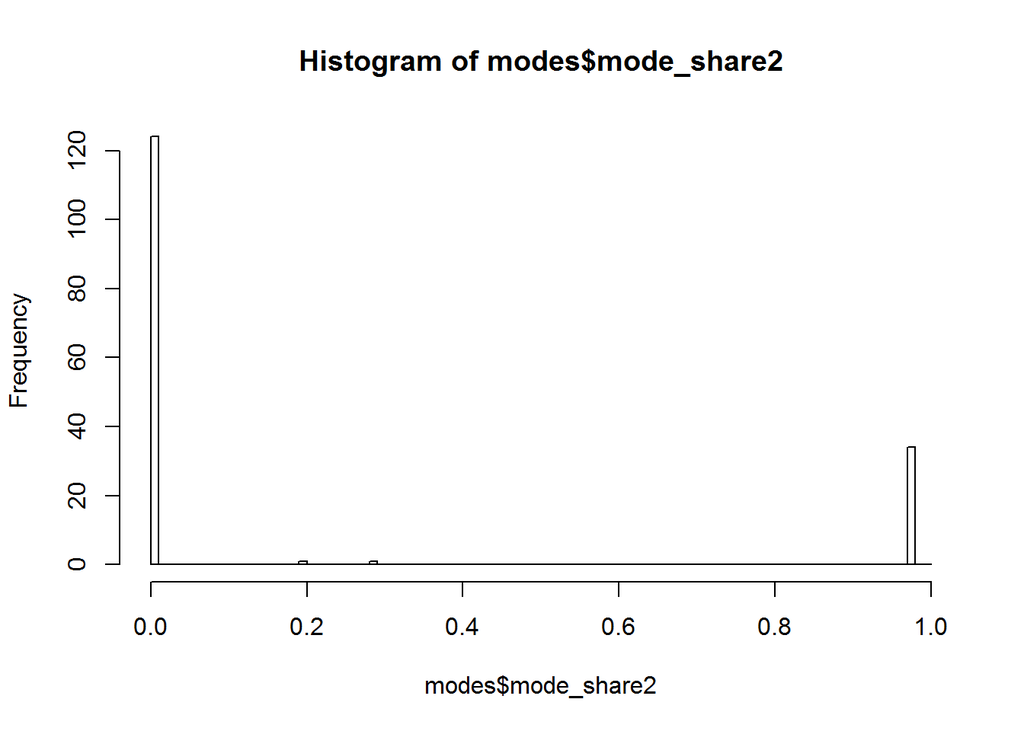

```r
hist(modes$mode_share2,breaks=seq(0,1,.01))
```

34 columns have the same value 97% of the time. I decide to remove these as the lack of variation will make them less useful. I also repeat the same exercise for columns with a large number of NAs. Lastly I remove the first column which is just row number (but does correlate with the exercise type so may mislead a model). I also remove columns 2 through 4 are timestamps (raw_timestamp_part_1 and raw_timestamep_part2 and cvtd_timestamp).

## Model Development

First split the training further into training and test.

```r
trainIndex <- createDataPartition(train$classe, p= .8, list=FALSE, times=1)
Cleaned_Train <- train_goodColsNA_wUser[trainIndex,]
Cleaned_Test <- train_goodColsNA_wUser[-trainIndex,]
```

# Regression Tree

```r
# --- Tree w defualt levels

modRPart <- train(classe~.,method="rpart",data=Cleaned_Train)
RPart_Prediction  <- predict(modRPart,Cleaned_Train,type="raw")
TreeResults<- confusionMatrix(RPart_Prediction,Cleaned_Train$classe)
TreeResults$overall[c(1,3:4)]
```

```
##      Accuracy AccuracyLower AccuracyUpper
##     0.5729027     0.5651202     0.5806582
```

```r
# --- Tree w 20 levels.
modRPart3 <- train(classe~.,method="rpart",data=Cleaned_Train,tuneLength=20)

RPart_Prediction_20  <- predict(modRPart3,Cleaned_Train,type="raw")
TreeResults20<- confusionMatrix(RPart_Prediction_20,Cleaned_Train$classe)
TreeResults20$overall[c(1,3:4)]
```

```
##      Accuracy AccuracyLower AccuracyUpper
##     0.8643863     0.8589312     0.8697060
```

```r
modTreeBag <- train(classe~.,method="treebag",data=Cleaned_Train)
```

```r
TreeBag_Prediction  <- predict(modTreeBag,Cleaned_Train,type="raw")
TreeBagResultsBag<- confusionMatrix(TreeBag_Prediction,Cleaned_Train$classe)
TreeBagResultsBag$overall[c(1,3:4)]
```

```
##      Accuracy AccuracyLower AccuracyUpper
##     0.9999363     0.9996451     0.9999984
```

This has near perfect accuracy.

## Out of sample error

The “treebag” already estimates a 95% confidence interval for accuracy of .999-1.000. I run this against the test set get my own data estimate.

```r
TreeBag_Prediction_Test  <- predict(modTreeBag,Cleaned_Test,type="raw")
TreeResultsTest<- confusionMatrix(TreeBag_Prediction_Test,Cleaned_Test$classe)
TreeResultsTest$overall[c(1,3:4)]
```

```
##      Accuracy AccuracyLower AccuracyUpper
##     0.9956666     0.9930708     0.9974737
```